# I-wave recruitment and synaptic plasticity in children born to women with gestational diabetes

Gestational diabetes mellitus (GDM) affects 5-10% of pregnancies, and is characterised by insulin resistance and, consequently, hyperglycemia. Children born to women with GDM are at greater risk of experiencing neurodevelopmental difficulties including ADHD, autism, and impaired motor and cognitive function. Recently we reported (Van Dam et al., 2018) lower and more variable neuroplastic responses to continuous theta burst stimulation (cTBS), a repetitive transcranial magnetic brain stimulation (TMS) techniques designed to induce an LTD-like neuroplastic response. An issue with data of this kind is its inherent variability.  
Recent research by Hamada et al. (2013) and Hordacre et al. (2017) suggests that inter-individual differences in the cortical network activated by TMS pulses can also influence the response. Because different populations of cortical neurons are stimulated more easily or are more excitable in different people at different times, and because these populations can contribute differently to neuroplastic responses, a substantial proportion of the variability in neuroplastic responses may be explained by variable interneuron recruitment, rather than by variability in synaptic function per se. The descending volley evoked by a single TMS pulse consists of several components. The earliest of these is believed to reflect the direct activation of the corticospinal output cells and is known as the “direct (D)-wave”. The later components result from indirect activation of output cells, and are known as “indirect (I)-waves”. Early I-waves likely result from monosynaptic input to corticospinal neurons from layer II/III interneurons, whereas later I-waves reflect the activity of more complex, oligosynaptic circuits (Di Lazzaro et al., 2012, Hordacre et al., 2017). Hamada et al. (2013) found that individuals in whom TMS was more likely to recruit late I-waves had stronger and more perdictable neuroplasticity. Similar results were observed by Hordacre et al. (2017). Although the mechanisms are unclear, Hamada et al. (2013) suggest that the late I-wave-generating circuitry may be more sensitive to TBS than the early I-wave-generating circuitry. Given that we previously observed both weaker and more variable neuroplastic responses to cTBS in children exposed to GDM when compared with a control group, we hypothesised that some of this variability may be due to I-wave recruitment variability rather than altered synaptic plasticity. Here is a simplified analysis of neuroplasticity and I-wave data examining their interrelation and whether each is influenced by in utero exposure to GDM.

...............................................................................................................................

## Import, clean, and prepare data for analysis

```python
# Import modules
import pandas as pd
import numpy as np
import matplotlib.pyplot as plt
import scipy.stats as stats
import statsmodels.api as sm
import statsmodels.formula.api as smf
from statsmodels.stats.anova import AnovaRM
import seaborn as sns

# Set global plotting style
plt.style.use('seaborn-talk')
```

```python
# define anova function to calculate effect sizes
def anova_table(aov):
    aov['mean_sq'] = aov[:]['sum_sq']/aov[:]['df']
    aov['eta_sq'] = aov[:-1]['sum_sq']/sum(aov['sum_sq'])
    aov['omega_sq'] = (aov[:-1]['sum_sq']-(aov[:-1]['df']*aov['mean_sq'][-1]))/(sum(aov['sum_sq'])+aov['mean_sq'][-1])
    cols = ['sum_sq', 'df', 'mean_sq', 'F', 'PR(>F)', 'eta_sq', 'omega_sq']
    aov = aov[cols]
    return aov
```

```python
# Load in the data,
df = pd.read_excel('data.xlsx')

# Select only relevant subjects (all subjects in current study have a non-null value for RMTS2)
df = df[df['MeanSuppression'].notnull()]
```

Checking for outliers:

Here we have found a neuroplasticity value that is very high relative to all others (and in absolute terms). It is likely due to data collection errors (which we won't go in to here), so we will treat it as an outlier. Note that this value does not change the conclusions drawn from results but does influence effect size.

```python
# calculate Z-scores for mean plasticity and assign to new column
df['msZ'] = np.abs(sp.zscore(df['MeanSuppression']))
print(df['msZ'].sort_values(ascending=False)[:5])

# one value is far larger than all the rest, so we'll filter this out
df_wo = df # keep a dataframe with the outlier, in case we want to compare
df = df[df['msZ'] < 2.5]
```

```
8     2.834567
3     1.739859
31    1.649519
13    1.353396
22    1.295144
Name: msZ, dtype: float64
```

```python
# Split data into the 2 groups
gdm = df[df['GDM'] == 1]
control = df[df['GDM'] == 0]
```

...............................................................................................................................

## Analysis

### I-waves and neuroplasticity

#### Response to cTBS

Here we'll look at the group-level response to cTBS in order to determine whether there was a net change in excitability among all of the participants.

```python
# converting plasticity data to long form for easier plotting in time-series (repeated measures) format
long_plas_gdm = pd.melt(gdm, id_vars='study_no', value_vars=[
                    'Baseline_S2', 'post0_S2', 'post5_S2', 'post10_S2', 'post20_S2', 'post30_S2'], var_name='time', value_name='plasticity')
long_plas_gdm['GDM'] = 'gdm'
long_plas_control = pd.melt(control, id_vars='study_no', value_vars=[
                    'Baseline_S2', 'post0_S2', 'post5_S2', 'post10_S2', 'post20_S2', 'post30_S2'], var_name='time', value_name='plasticity')
long_plas_control['GDM'] = 'control'

long_plas = long_plas_gdm.append(long_plas_control, ignore_index=True)
long_plas.head()
```

|  | study_no | time | plasticity | GDM |
| --- | --- | --- | --- | --- |
| 0 | 1411 | Baseline_S2 | 100.0 | gdm |
| 1 | 1833 | Baseline_S2 | 100.0 | gdm |
| 2 | 2045 | Baseline_S2 | 100.0 | gdm |
| 3 | 2060 | Baseline_S2 | 100.0 | gdm |
| 4 | 2152 | Baseline_S2 | 100.0 | gdm |

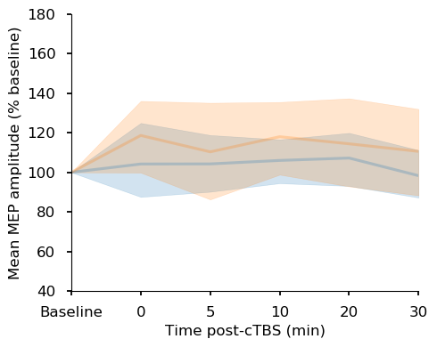

```python
# Plotting group responses to cTBS over time
fig, ax = plt.subplots(figsize=(5,4), dpi=100)

sns.lineplot(x='time', y='plasticity', hue='GDM',
                 data=long_plas, legend=None, alpha=0.25)

ax.set_xticklabels(['Baseline', '0', '5', '10', '20', '30'], fontsize=12)
ax.tick_params(axis='y', which='major', labelsize=12)
ax.set_xlabel('Time post-cTBS (min)', fontsize=12)
ax.set_ylabel('Mean MEP amplitude (% baseline)', fontsize=12)
ax.set_xlim((0,5))
ax.set_ylim((40, 180))

sns.despine(fig)
plt.tight_layout()
```

To test for a group-level neuroplastic effect, we'll need to use the raw data (not the baseline-normalised data we use elsewhere). First we'll convert it long-form:

```python
# converting raw plasticity data to long form
long_plas_raw = pd.melt(df, id_vars='study_no', value_vars=[
                        'RawBaseline_S2', 'Raw0_S2', 'Raw5_S2', 'Raw10_S2', 'Raw20_S2', 'Raw30_S2'], var_name='time', value_name='plasticity')
long_plas_raw.head()
```

|  | study_no | time | plasticity |
| --- | --- | --- | --- |
| 0 | 1411 | RawBaseline_S2 | 0.821578 |
| 1 | 1833 | RawBaseline_S2 | 0.908226 |
| 2 | 2045 | RawBaseline_S2 | 1.438080 |
| 3 | 2060 | RawBaseline_S2 | 0.973905 |
| 4 | 2152 | RawBaseline_S2 | 0.856295 |

```python
aovrm = AnovaRM(data=long_plas_raw, depvar='plasticity', subject='study_no', within=['time']).fit()
print(aovrm)
```

```
               Anova
===================================
     F Value Num DF  Den DF  Pr > F
-----------------------------------
time  0.9914 5.0000 145.0000 0.4252
===================================
```

Analysis of the raw EMG data found no (group-level) effect of time; that is, the group as a whole did not respond to cTBS. However, this does not mean that individuals did not respond -- the responses can go in either direction and can cancel each other out when averaged. Soon, we'll see whether using I-waves we can separate people into 'responders' and 'non-responders'.

#### Neuroplasticity and I-wave latencies by GDM group

Here we will explore whether neuroplastic responses or AP-LM latency differences differ bewteen groups (GDM vs control).

I-wave recruitment is measured here as the difference in latencies of MEPs evoked with different TMS coil orientations. Different orientations induce an electric current in the brain in different directions, stimulating the motor cortex from different angles and involving different circuits. These circuits are infuenced by TBS differently, and individuals who respond well to cTBS and iTBS tend to have greater latency differences between MEPs induced with lateromedial (LM) and anterior-posterior (AP) currents, as their AP latencies will be longer as a result of more complex circuits being involved in production of an MEP.

```python
# Plasticity characteristics
print('Plasticity:', '\n', 'GDM -', 'Mean:', round(gdm['MeanSuppression'].mean(), 2), '| SD:', round(gdm['MeanSuppression'].std(), 2))
print('Control -', 'Mean:', round(control['MeanSuppression'].mean(), 2), '| SD:', round(control['MeanSuppression'].std(), 2), '\n')

print(sp.ttest_ind(gdm['MeanSuppression'], control['MeanSuppression'], nan_policy='omit'), '\n')

print(df['MeanSuppression'].describe())
```

```
Plasticity:
 GDM - Mean: 104.01 | SD: 27.98
Control - Mean: 114.41 | SD: 31.53

Ttest_indResult(statistic=-0.9215175063392365, pvalue=0.36465270666991056)

count     30.000000
mean     107.474790
std       29.087963
min       66.082531
25%       77.997127
50%      107.358923
75%      120.474058
max      167.786999
Name: MeanSuppression, dtype: float64
```

We can see above that the groups did not differ in average response to cTBS. When looking at the whole sample, it is apparent that some individuals have an inhibition-like response (as expected, MEP amplitudes decrease), while some have facilitation-like responses (the opposite of what is expected).

```python
# AP-LM characteristics
print('AP-LM:', '\n', 'GDM -', 'Mean:', round(gdm['ap_lm'].mean(), 2), '| SD:', round(gdm['ap_lm'].std(), 2))
print('Control -', 'Mean:', round(control['ap_lm'].mean(), 2), '| SD:', round(control['ap_lm'].std(), 2),'\n')

print(sp.ttest_ind(gdm['ap_lm'], control['ap_lm'], nan_policy='omit'), '\n')

print(df['ap_lm'].describe())
```

```
AP-LM:
 GDM - Mean: 3.53 | SD: 0.79
Control - Mean: 3.62 | SD: 1.48

Ttest_indResult(statistic=-0.20504287625461684, pvalue=0.8390219518520128)

count    30.000000
mean      3.559485
std       1.043856
min       1.569141
25%       2.804796
50%       3.515162
75%       4.028047
max       6.033438
Name: ap_lm, dtype: float64
```

Mean I-wave recruitment (AP-LM latency) also doesn't differ between groups. Let's plot this:

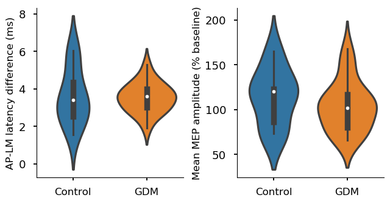

```python
fig, axes = plt.subplots(1, 2, sharex=True, dpi=100, figsize=(6.5,3.5))

sns.violinplot(x='GDM', y='ap_lm', data=df, ax=axes[0])
axes[0].set_ylabel('AP-LM latency difference (ms)', fontsize=12)

sns.violinplot(x='GDM', y='MeanSuppression', data=df, ax=axes[1])
axes[1].set_ylabel('Mean MEP amplitude (% baseline)', fontsize=12)

for ax in axes:
    ax.set_xlabel('')
    ax.set_xticklabels(['Control', 'GDM'], fontsize=12)

sns.despine(fig)
plt.tight_layout()
```

Indeed, the central tendency of both neuroplasticity (right) and I-wave recruitment (left) is similar in each group. However, it appears that there is lower variability and a smaller range of I-waves in the GDM group. This is interesting because the GDM group is twice as large (and therefore had greater opportunity to express extreme values). This might be physiologically relevant, so let's look a little closer.

#### Distribution of AP-LM by group

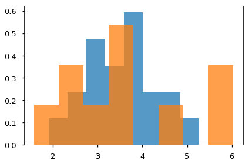

```python
# Viewing distributions of AP-LM for each group
plt.hist(gdm['ap_lm'], alpha=0.75, bins=8, density=True)
plt.hist(control['ap_lm'], alpha=0.75, bins=8, density=True)
plt.tight_layout()
```

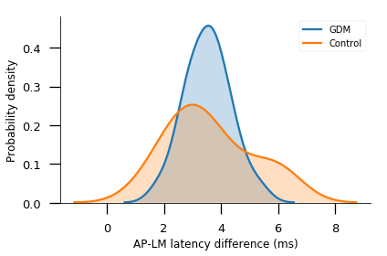

```python
# A prettier way
fig, ax = plt.subplots()#figsize=[5,4], dpi=300)
sns.kdeplot(gdm['ap_lm'], shade=True)
sns.kdeplot(control['ap_lm'], shade=True)

plt.legend(('GDM','Control'), fontsize=10)
ax.tick_params(axis='both', size=12)
ax.set_xlabel('AP-LM latency difference (ms)', fontsize=12)
ax.set_ylabel('Probability density', fontsize=12)

sns.despine()
plt.tight_layout()

#plt.savefig('Figures/AP-LM_probdensity_kde.png')
#plt.savefig('Figures/AP-LM_probdensity_kde.tiff')
#plt.savefig('Figures/AP-LM_probdensity_kde.pdf')
```

The kernel density estimation plot provides similar information to the violin plot's edges, but is arguably easier to interpret. There does appear to be less kurtosis in the GDM distribution, but let's see if there is a statistical difference in variances.

```python
# Testing for equal sphericity/variances
print('AP-LM latency:', sp.bartlett(gdm['ap_lm'], control['ap_lm']))
```

```
AP-LM latency: BartlettResult(statistic=4.9798564814577375, pvalue=0.0256441104727907)
```

```python
# Levene's test provides a similar result
print(sp.levene(gdm['ap_lm'], control['ap_lm'], center='mean'))
```

```
LeveneResult(statistic=4.517847950100666, pvalue=0.04249982323019232)
```

So, the variability in I-waves is lower in the GDM group. This may be relevant when comparing the relation between AP-LM and neuroplasticity between groups, as we'll see below. This also may be physiologically relevant to in other way, but that's a topic for future research.

### AP-LM latency predicts neuroplasticity

Now, let's see if I-wave recruitment can predict the neuroplastic response to cTBS.

```python
# predicting plasticity with AP-PA latency using statsmodels formula syntax (great for R users!)
results = smf.ols('MeanSuppression ~ ap_pa', data=df, missing='drop').fit()
#print(results.summary())
aov_table = sm.stats.anova_lm(results, typ=2)
print(anova_table(aov_table))
```

```
                sum_sq    df      mean_sq         F    PR(>F)   eta_sq  \
ap_pa      5062.519097   1.0  5062.519097  7.278717  0.011686  0.20632
Residual  19474.658486  28.0   695.523517       NaN       NaN      NaN

          omega_sq
ap_pa     0.173069
Residual       NaN
```

It does! This is a fairly strong effect, too, explaining around 20% of the variability in cTBS response. Trust me, that's a lot.

Let's visualise this association.

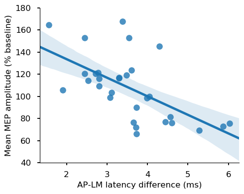

```python
fig, ax = plt.subplots(dpi=100, figsize=(5,4))

sns.regplot(x='ap_lm', y='MeanSuppression', data=df)
ax.set_ylabel('Mean MEP amplitude (% baseline)', fontsize=12)
ax.set_xlabel('AP-LM latency difference (ms)', fontsize=12)
ax.tick_params(axis='both', labelsize=12)
plt.ylim((40, 180))

sns.despine(fig)
plt.tight_layout()
```

That's quite a nice negative, linear association, and it's what we expect based on the adult studies (Hamada et al., 2013; Hordacre et al., 2017).

Now we want to know if this effect is different in the GDM group compared with the control group.

### Comparing the AP-LM and plasticity association between groups

First, we'll look at the strength of the association in each group.

```python
# adding group to the model, and looking for an interaction effect
results = smf.ols('MeanSuppression ~ ap_pa', data=control).fit()
#print(results.summary())
aov_table = sm.stats.anova_lm(results, typ=2)
print(anova_table(aov_table))
```

```
               sum_sq   df      mean_sq          F   PR(>F)    eta_sq  \
ap_pa     6425.335964  1.0  6425.335964  20.396618  0.00196  0.718276
Residual  2520.157421  8.0   315.019678        NaN      NaN       NaN

          omega_sq
ap_pa     0.659825
Residual       NaN
```

```python
# adding group to the model, and looking for an interaction effect
results = smf.ols('MeanSuppression ~ ap_pa', data=gdm).fit()
#print(results.summary())
aov_table = sm.stats.anova_lm(results, typ=2)
print(anova_table(aov_table))
```

```
                sum_sq    df     mean_sq         F    PR(>F)    eta_sq  \
ap_pa        51.370444   1.0   51.370444  0.062401  0.805568  0.003455
Residual  14818.046220  18.0  823.224790       NaN       NaN       NaN

          omega_sq
ap_pa    -0.049186
Residual       NaN
```

Wow. The association is very strong in the control group, but weak in the GDM group.

Let's see if there's an interaction effect, and then plot the regression lines for each group.

```python
# adding group to the model, and looking for an interaction effect
results = smf.ols('MeanSuppression ~ C(GDM) * ap_pa', data=df).fit()
#print(results.summary())
aov_table = sm.stats.anova_lm(results, typ=2)
print(anova_table(aov_table))
```

```
                    sum_sq    df      mean_sq         F    PR(>F)    eta_sq  \
C(GDM)          446.861830   1.0   446.861830  0.670104  0.420455  0.018418
ap_pa          4787.113391   1.0  4787.113391  7.178653  0.012626  0.197311
C(GDM):ap_pa   1689.593016   1.0  1689.593016  2.533678  0.123527  0.069640
Residual      17338.203641  26.0   666.853986       NaN       NaN       NaN

              omega_sq
C(GDM)       -0.008825
ap_pa         0.165282
C(GDM):ap_pa  0.041027
Residual           NaN
```

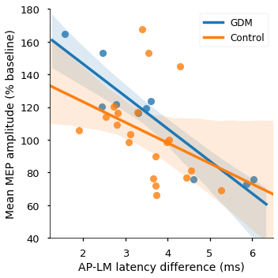

```python
g=sns.lmplot(x='ap_lm', y='MeanSuppression', data=df, hue='GDM', height=5, aspect=1, legend=None)

plt.xlim((1.2, 6.5))
plt.ylim((40, 180))
plt.ylabel('Mean MEP amplitude (% baseline)', fontsize=14)
plt.xlabel('AP-LM latency difference (ms)', fontsize=14)
plt.legend(('GDM', 'Control'), fontsize=12)

plt.tight_layout()
```

Hmm. The strength of the association seemed wildly different in each group when assessed individually, but there was no interaction effect between group and AP-LM when predicting plasticity. When looking at the graph, the association doesn't look that much weaker in the GDM group. This is probably a case of small sample size relative to variability resulting in a misleading result. From this, we could reasonably conclude that the effect we're observing is similar in each of these groups.

```python
# bonus analysis (for fun)
# bootstrap samples and ANCOVAs to test bootstrapped interaction effects
interaction_pvalues = []

for i in range(1000):
    gdm_sample = gdm.sample(n=15, replace=True)
    control_sample = control.sample(n=15, replace=True)
    bs_sample = gdm_sample.append(control_sample)
    reg = smf.ols(formula='MeanSuppression ~ C(GDM) * ap_lm',
               data=bs_sample, missing='drop').fit()
    interaction_pvalues.append(reg.pvalues[3])

print(np.mean(interaction_pvalues))
```

```
0.41996689932254305
```

### Split on AP-LM latency

Given the effect of I-waves on neuroplastic response, it is interesting to know whether I-wave recruitment can be used to categorize an individual into neuroplastic response groups, i.e., whether their MEPs were facilitated or inhibited in response to cTBS.

To this end we will split the subjects into groups based on the AP-LM latency difference and compare neuroplastic responses:

```python
# median split on ap-lm latency difference
median = np.median(df['ap_lm'])
med_split_late = df[df['ap_lm'] >= median]
med_split_early = df[df['ap_lm'] < median]
print('Median:', median)
print('Late I-wave group plasticity (mean | SD):', med_split_late['MeanSuppression'].mean(), ' | ', med_split_late['MeanSuppression'].std())
print('Early I-wave group plasticity (mean | SD):', med_split_early['MeanSuppression'].mean(), ' | ', med_split_early['MeanSuppression'].std())
m = sp.ttest_ind(med_split_late['MeanSuppression'], med_split_early['MeanSuppression'])
print('p =', format(m[1], '.5f'))
```

```
Median: 3.5151620279999998
Late I-wave group plasticity (mean | SD): 91.74233561599999  |  27.7065770415088
Early I-wave group plasticity (mean | SD): 123.20724489933333  |  21.321873330525307
p = 0.00164
```

Indeed, individuals with short I-waves are more likely to exhibit facilitation of MEPs (the opposite of the expected response).

Similarly, we can test whether I-waves are different based on neuroplastic response direction:

```python
# split by response direction and compare latencies
ltp = df[df['MeanSuppression'] >= 100]
ltd = df[df['MeanSuppression'] < 100]

print('LTP group AP-LM (mean | SD):', ltp['ap_lm'].mean(), ' | ', ltp['ap_lm'].std())
print('LTD group AP-LM (mean | SD):', ltd['ap_lm'].mean(), ' | ', ltd['ap_lm'].std())
m = sp.ttest_ind(ltp['ap_lm'], ltd['ap_lm'])
print('p =', format((m[1]), '.5f'))
```

```
LTP group AP-LM (mean | SD): 2.944334264117647  |  0.6670797995402942
LTD group AP-LM (mean | SD): 4.363912748307692  |  0.8960163600689255
p = 0.00003
```

Indeed they are. Let's see if there are main effects of time in each group, and then visualise plasticity by I-wave group.

```python
# Converting median split data to visualize MEP change over time by subject and by group
medsplit_early_long = pd.melt(med_split_early, id_vars='study_no', value_vars=[
                    'Baseline_S2', 'post0_S2', 'post5_S2', 'post10_S2', 'post20_S2', 'post30_S2'], var_name='time', value_name='plasticity')
medsplit_late_long = pd.melt(med_split_late, id_vars='study_no', value_vars=[
                    'Baseline_S2', 'post0_S2', 'post5_S2', 'post10_S2', 'post20_S2', 'post30_S2'], var_name='time', value_name='plasticity')
```

```python
# Early I-waves group
aovrm = AnovaRM(data=medsplit_early_long, depvar='plasticity', subject='study_no', within=['time']).fit()
print(aovrm)
```

```
              Anova
==================================
     F Value Num DF  Den DF Pr > F
----------------------------------
time  3.5730 5.0000 70.0000 0.0062
==================================
```

```python
# Late I-waves group
aovrm = AnovaRM(data=medsplit_late_long, depvar='plasticity', subject='study_no', within=['time']).fit()
print(aovrm)
```

```
              Anova
==================================
     F Value Num DF  Den DF Pr > F
----------------------------------
time  0.9449 5.0000 70.0000 0.4576
==================================
```

#### Visualizing individual responses by latency group

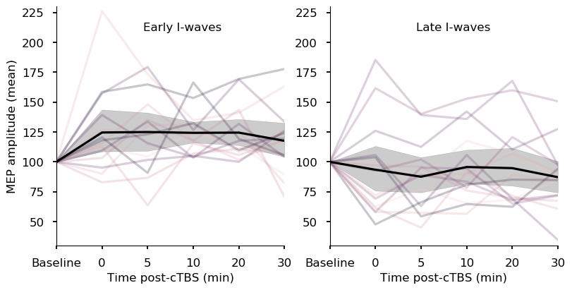

```python
fig, axes = plt.subplots(1, 2, sharex=True, figsize=(8,4), dpi=100)

sns.lineplot(x='time', y='plasticity', hue='study_no',
             data=medsplit_early_long, legend=None, alpha=0.25, ax=axes[0])
sns.lineplot(x='time', y='plasticity',
             data=medsplit_early_long, legend=None, alpha=1, color='black', ax=axes[0])
axes[0].set_ylabel('MEP amplitude (mean)', size=12)
axes[0].text(1.9, 210, 'Early I-waves', fontsize=12)


sns.lineplot(x='time', y='plasticity', hue='study_no',
             data=medsplit_late_long, legend=None, alpha=0.25, ax=axes[1])
sns.lineplot(x='time', y='plasticity',
             data=medsplit_late_long, legend=None, alpha=1, color='black', ax=axes[1])
axes[1].set_ylabel('',)
axes[1].text(1.9, 210, 'Late I-waves', fontsize=12)

for ax in axes:
    ax.set_xlabel('Time post-cTBS (min)', size=12)
    ax.set_xticklabels(['Baseline', '0', '5', '10', '20', '30'], fontsize=12)
    ax.tick_params(axis="y", labelsize=12)
    ax.set_ylim([30, 230])
    ax.set_xlim([0, 5])

sns.despine(fig)
plt.tight_layout(pad=0.3)
```

As expected, mean neuroplastic responses were mostly inhibitory in individuals in whom late I-waves were evoked, and facilitatory in those in whom late I-waves were not evoked, based on a median split of AP-LM corresponding to latencies above or below ~ 3.5 ms. Note that this value is physiologically relevant as late I-waves (as evoked with AP current) should be 3+ ms longer than D-waves (evoked with high-intensity LM current). Similar results are observed when splitting the group at 4ms AP-LM, as in the Hamada et al. study (not shown here).

Similarly, when splitting the group on neuroplastic response direction (facilitatory or inhibitory), we see a significant difference in AP-LM latency, with < 3 ms in the facilitation (LTP) group, and > 4 ms in the inhibitory (LTD) group.

## Conclusions

Here we saw evidence that the association between interneuron recruitment (I-waves) and the neuroplastic response to cTBS, whereby longer I-waves are associated with stronger, inhibition-like responses, is present in adolescents. We also saw that, although I-wave recruitment may follow a narrower distribution in GDM-exposed offspring, the effect is likely similar in this group.

These results are important in interpreting and optimising cTBS, a technique used both in basic physiological research and in the clinic for the treatment of major depressive disorder.

They also show the exposure to GDM does not lead to significant changes in the forms of synaptic plasticity involved in the response to cTBS.

See Van Dam et al., 2018, for more detail.

## References

HAMADA, M., MURASE, N., HASAN, A., BALARATNAM, M. & ROTHWELL, J. C. 2013. The role of interneuron networks in driving human motor cortical plasticity. Cereb Cortex, 23, 1593-605.

HORDACRE, B., GOLDSWORTHY, M. R., VALLENCE, A. M., DARVISHI, S., MOEZZI, B., HAMADA, M., ROTHWELL, J. C. & RIDDING, M. C. 2017. Variability in neural excitability and plasticity induction in the human cortex: A brain stimulation study. Brain Stimul, 10, 588-595.

VAN DAM, J. M., GARRETT, A. J., SCHNEIDER, L. A., HODYL, N. A., GOLDSWORTHY, M. R., COAT, S., ROWAN, J. A., HAGUE, W. M. & PITCHER, J. B. 2018. Reduced Cortical Excitability, Neuroplasticity, and Salivary Cortisol in 11-13-Year-Old Children Born to Women with Gestational Diabetes Mellitus. EBioMedicine, 31, 143-149.